# Applied data science capstone - The battle of Neighbourhoods in the city of Bari

### Final report week 5 - Data Science by IBM

## Introduction and Business problem

In this final project I focused on parsing and segmenting Bari's neighbours data in order to find the best location in which open a new international food restaurant. Bari is the largest city of Puglia, Italy and it's known for its food tradition, in particular seafood and fresh seafood. Since its food tradition there are very few international options that are mostly Greek or middle-east food restaurant. In this work I simulate to be an investor who wants to open a Mexican or Thai restaurant.

## Data collection and description

Data were acquired from https://en.wikipedia.org/wiki/Bari#Quarters. After exploring a bit the data and using foursquare API to collect informations about venues present over Bari's neighbourhood I focused mostly on restaurants and I create a dataframe that collect infos about Neighbours, their coordinates (latitude and longitude) and the most common venues that chracterize those boroughs.

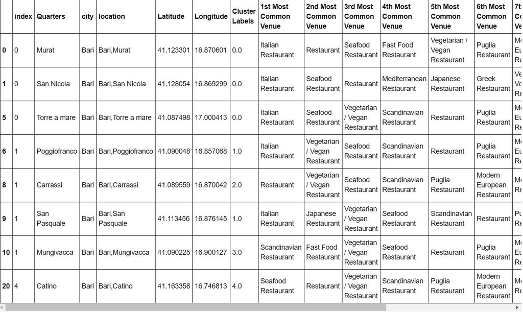

## Methodolgy

Once selected only restaurant venues I decided to plot a histogram that could highlight the frequency of every restaurant type across all the neighbourhoods

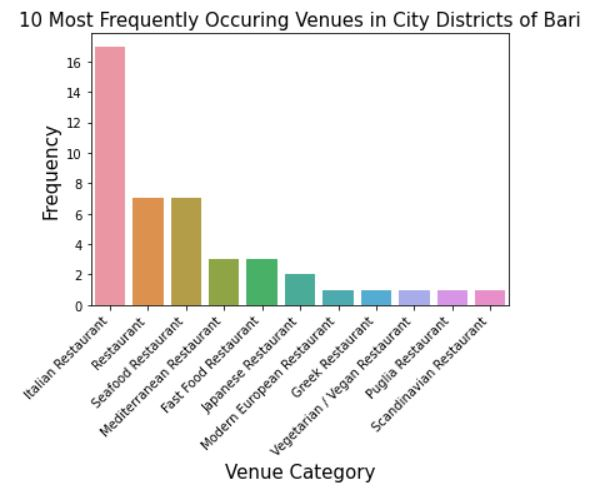

I used k-means clustering in order to group neighbours by restaurant types and numbers and then I used folium package to plot those clusters.

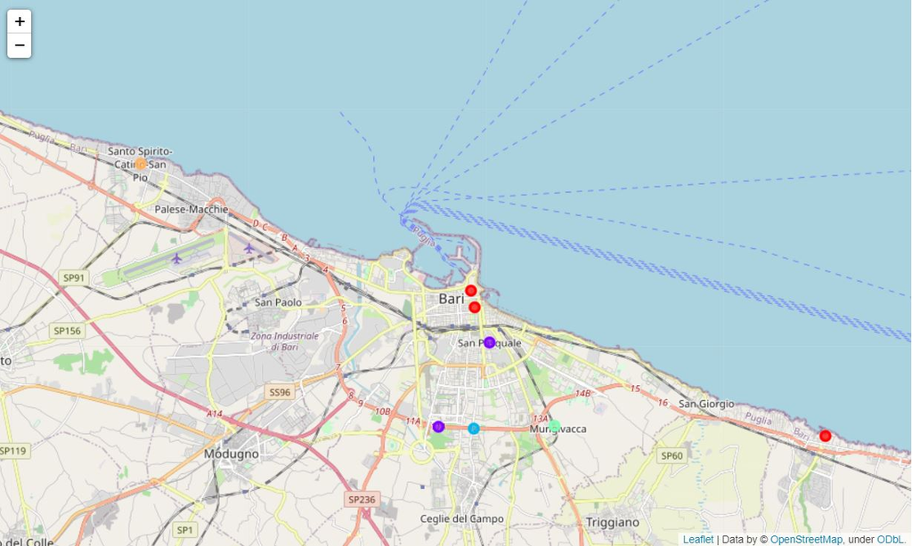

Once clusters have been created I analyzed each of the identified groups in order to highlight clusters characteristics.

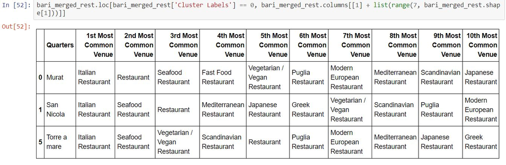

## Discussion

After cleaning and parsing data about Restaurant clustering around the city of Bari we can see that there are few neighbours that contain the majority of restaurant of the entire area. The following table highlights the total number of restaurants per neighbours.

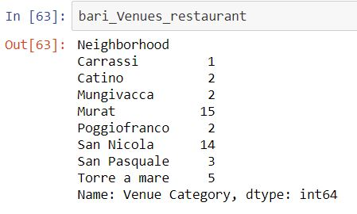

### Top 3

We can state that "Murat" and "San Nicola" are the top two neighbours if we consider the number of operating restaurants. This is consistent with the fact that these are two central neighbours located in the turistic area of the city.

The third neighbours in absolute number of restaurant is "Torre a Mare" which is a small centre near Bari that is famous for its seafood restaurant which are characterized by their view. All of the restaurant are located by the sea so it is very popular if you wanna experience a meal in front of the blue adriatic sea.

These three neighbours represent cluster 0 and of course they are the best choice if an investor want to open a new activity. The centrality of these with respect to the city and their touristic attraction that characterize these borough are the two major reason that attract someone to invest on.

### Top 4th and 5th

The cluster number 1 respresent a very peculiar group. This is composed by "Poggiofranco" and "San Pasquale" that are the Univeristy neighbours. These represent good neighbours marked by young people in which one can experience vegetarian, vegan and international food.

### Cluster n.3

Cluster n 3 represents a very peculiar one. It is located at city borders and it's characterized by fast food located on the highway.